# Part II - Factors Used to Determine Loan Grants

## by TANWIE RANDY FUNWIE

## Investigation Overview

In this investigation, I wanted to look at the characteristics of loans that could be used to predict their borrower Rate. The main focus was on the Employment Status,Loan Status,IsBorrowerHomeowner and Stated Monthly Income.

## Dataset Overview

The dataset consisted of borrower Interest and attributes of 113,937 loans. The attributes included original loan amount, borrower's Prosper rating, loan term, borrower's stated monthly income, as well as many other features such as borrower's employment status, debt to income ratio, current loan status etc. The dataset can be found [here](https://s3.amazonaws.com/udacity-hosted-downloads/ud651/prosperLoanData.csv), with feature documentation available [here](https://docs.google.com/spreadsheets/d/1gDyi_L4UvIrLTEC6Wri5nbaMmkGmLQBk-Yx3z0XDEtI/edit#gid=0)

## Distribution of Loan Status

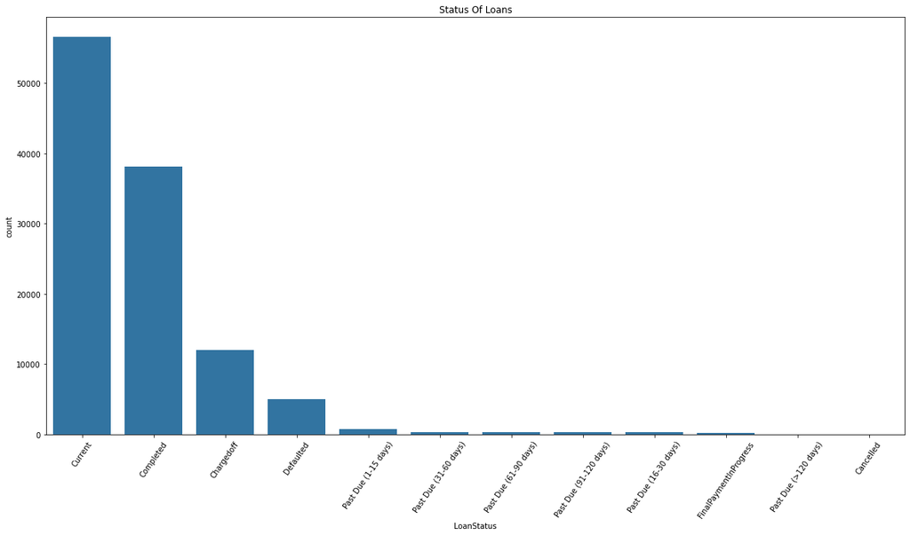

## Distribution of Employment Status

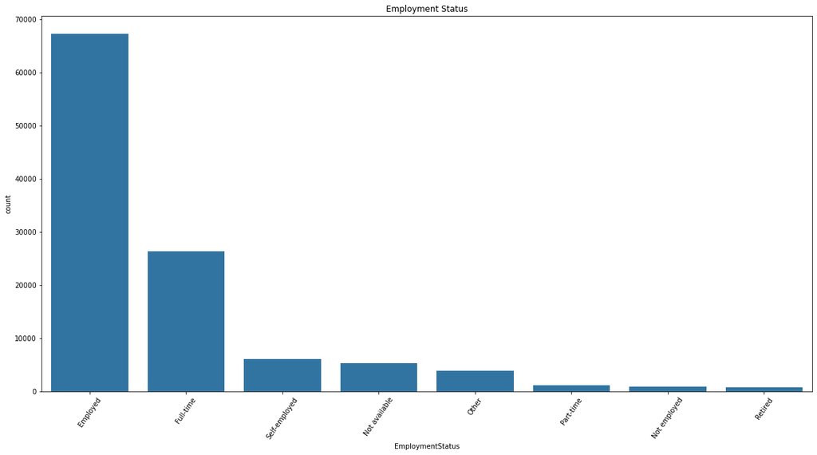

## Distribution Of Borrower Rate

The distribution is multimodal.A small number of loans were offered from 0 to 4% and starts by having an increase from 5%, with the first spike at 14% and 15%. Another comes at 19% with the highest at 32%. From 35% there were little rates found.

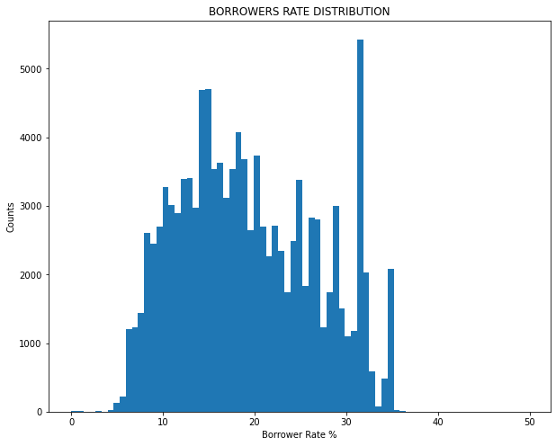

## Distribution of Borrower Rate Over The Completed,Chargedoff and Defaulted Loans

The second shows a distribution of the Borrowers's rate which were chargedoff. The distribution here too is multimodel and with a total of 11992 loans chargedoff most with have the highest number at the 31% and 32% rates.

The Defaulted distribution with total number of 5018 loans has the highest number of defaulted loans at 29%.

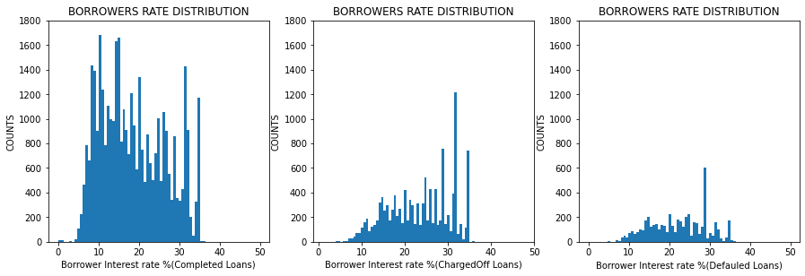

## The Relationship Between Employment Status and Borrower's Rate

In medians for most of the Employemtent status were between 10% to 20% with most of the distribution around that area. The one that stood out the most was the Not employed distribution of which had the large number of rates aound the 30%.

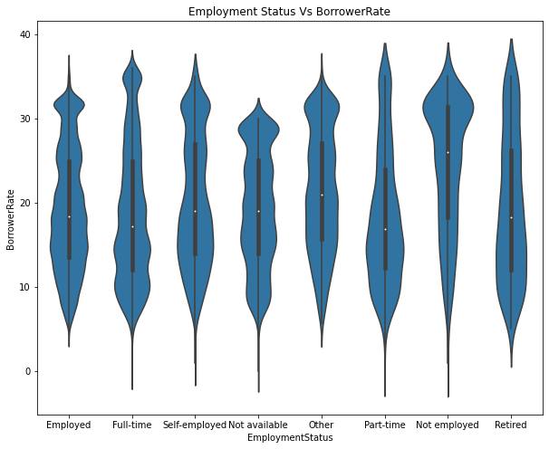

## Income Range vs Employment Status vs IsBorrowerHomeOwner'

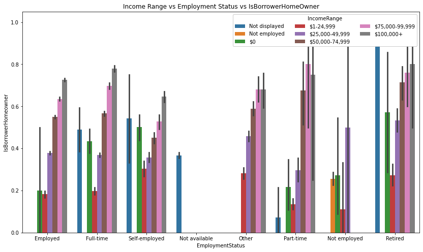

This next graph is clearer and focuses more on the employed

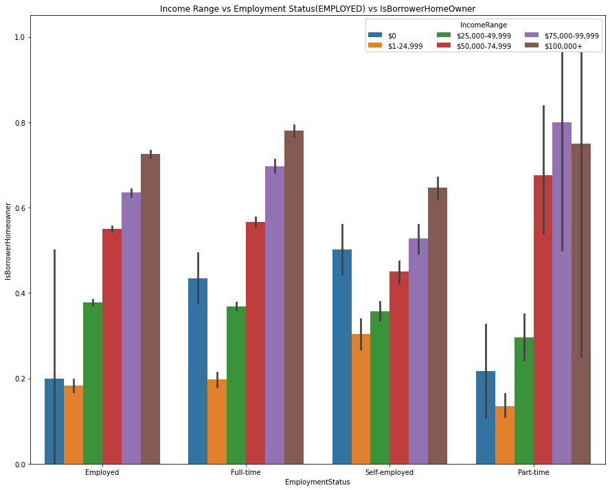